# Einführung in die Darstellung und Interpolation von räumlicher Daten mit R

11 Februar 2018

## Inhalt

- sp package und räumliche Datentypen
- Beispieldatensatz MEUSE - Schwermetallkonzentrationen im Mutterboden einer Flussaue
- Graphische Darstellungen
- Interpolationsmethoden

## Motivation

- MEUSE ein klassikler Geostatistikdatensatz und wurde auch im Kurs DAT203.3x Applied Machine Learning (EDX.org) verwendet.

## sp package und räumliche Datentypen

- sp liefert Klassen und Methoden um Punkte, Linien, Polygone und Grids zu erstellen und zu bearbeiten.
- Die ‘Spatial’ Klasse ist die fundamentale Klasse aller räumlichen Datentypen in sp.

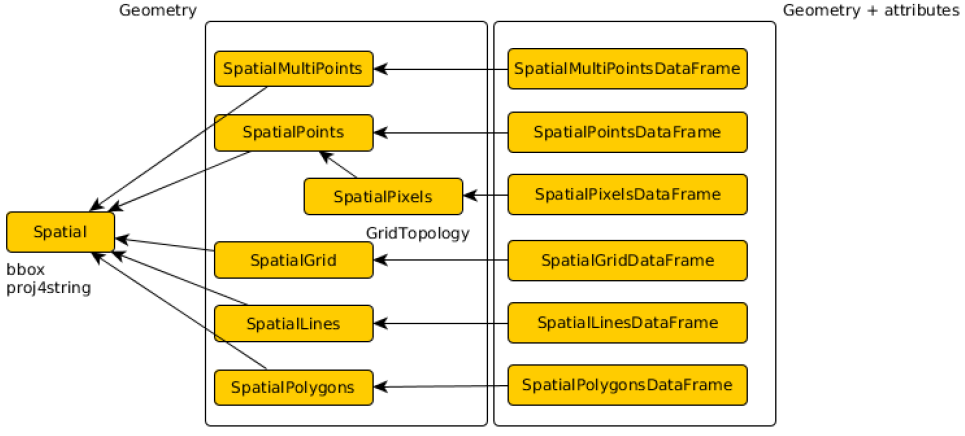

```r
knitr::include_graphics("sp_spacial_data_types_classes_overview.png")
```

## Laden der Libraries

```r
library(sp)
library(leaflet)
library(gstat)
library(ggplot2)
```

## MEUSE Datensatz

### Beschreibung

- Gemessene Schweremetallkonzentrationen im Mutterboden einer Flussaue
- Sowie weitere Boden- und Landschaftseigenschaften
- Fluss Meuse nahe dem Dorf Stein (Niederlande)
- Koordinatensystem: EPSG:28992 (Amersfoort/RD New)

### Laden der Daten

```r
# data loading
data("meuse")
class(meuse)
```

```
## [1] "data.frame"
```

```r
data("meuse.grid")
class(meuse.grid)
```

```
## [1] "data.frame"
```

### MEUSE - Daten Summary

```r
summary(meuse)
```

```
##        x                y             cadmium           copper
##  Min.   :178605   Min.   :329714   Min.   : 0.200   Min.   : 14.00
##  1st Qu.:179371   1st Qu.:330762   1st Qu.: 0.800   1st Qu.: 23.00
##  Median :179991   Median :331633   Median : 2.100   Median : 31.00
##  Mean   :180005   Mean   :331635   Mean   : 3.246   Mean   : 40.32
##  3rd Qu.:180630   3rd Qu.:332463   3rd Qu.: 3.850   3rd Qu.: 49.50
##  Max.   :181390   Max.   :333611   Max.   :18.100   Max.   :128.00
##
##       lead            zinc             elev             dist
##  Min.   : 37.0   Min.   : 113.0   Min.   : 5.180   Min.   :0.00000
##  1st Qu.: 72.5   1st Qu.: 198.0   1st Qu.: 7.546   1st Qu.:0.07569
##  Median :123.0   Median : 326.0   Median : 8.180   Median :0.21184
##  Mean   :153.4   Mean   : 469.7   Mean   : 8.165   Mean   :0.24002
##  3rd Qu.:207.0   3rd Qu.: 674.5   3rd Qu.: 8.955   3rd Qu.:0.36407
##  Max.   :654.0   Max.   :1839.0   Max.   :10.520   Max.   :0.88039
##
##        om         ffreq  soil   lime       landuse       dist.m
##  Min.   : 1.000   1:84   1:97   0:111   W      :50   Min.   :  10.0
##  1st Qu.: 5.300   2:48   2:46   1: 44   Ah     :39   1st Qu.:  80.0
##  Median : 6.900   3:23   3:12           Am     :22   Median : 270.0
##  Mean   : 7.478                         Fw     :10   Mean   : 290.3
##  3rd Qu.: 9.000                         Ab     : 8   3rd Qu.: 450.0
##  Max.   :17.000                         (Other):25   Max.   :1000.0
##  NA's   :2                              NA's   : 1
```

### MEUSE.GRID - Daten Summary

```r
summary(meuse.grid)
```

```
##        x                y              part.a           part.b
##  Min.   :178460   Min.   :329620   Min.   :0.0000   Min.   :0.0000
##  1st Qu.:179420   1st Qu.:330460   1st Qu.:0.0000   1st Qu.:0.0000
##  Median :179980   Median :331220   Median :0.0000   Median :1.0000
##  Mean   :179985   Mean   :331348   Mean   :0.3986   Mean   :0.6014
##  3rd Qu.:180580   3rd Qu.:332140   3rd Qu.:1.0000   3rd Qu.:1.0000
##  Max.   :181540   Max.   :333740   Max.   :1.0000   Max.   :1.0000
##       dist        soil     ffreq
##  Min.   :0.0000   1:1665   1: 779
##  1st Qu.:0.1193   2:1084   2:1335
##  Median :0.2715   3: 354   3: 989
##  Mean   :0.2971
##  3rd Qu.:0.4402
##  Max.   :0.9926
```

## MEUSE - Erstellen der Räumlichen Daten

```r
# creating spatial data
coordinates(meuse) <- ~x+y # Use x and y as coordinate
coordinates(meuse.grid) = ~x+y
# set spacial reference used in the meuse data
proj4string(meuse) <- CRS("+init=epsg:28992")
proj4string(meuse.grid) <- CRS("+init=epsg:28992")
gridded(meuse.grid) = TRUE

class(meuse)
```

```
## [1] "SpatialPointsDataFrame"
## attr(,"package")
## [1] "sp"
```

```r
class(meuse.grid)
```

```
## [1] "SpatialPixelsDataFrame"
## attr(,"package")
## [1] "sp"
```

## MEUSE - Darstellung der Bleikonzentration

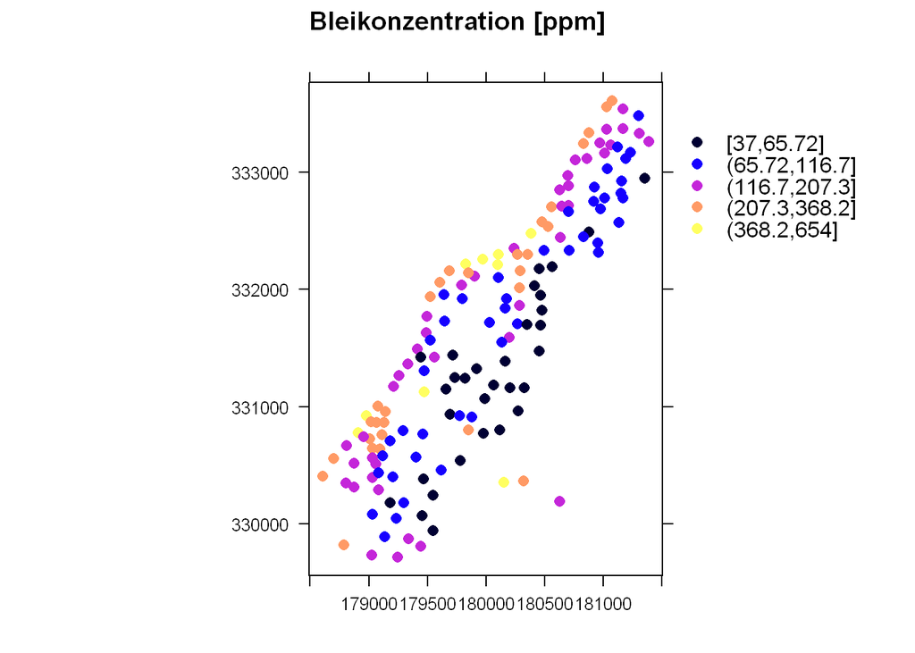

```r
spplot(meuse, "lead", do.log = TRUE,
    key.space=list(x=1.05,y=0.9,corner=c(0,1)),
    scales=list(draw=T),
    main = "Bleikonzentration [ppm]")
```

## MEUSE - Interaktive Darstellung

### Transformation zu WGS84

- Openstreet-Basemap ist in WGS84

```r
WGS84 <- CRS("+proj=longlat +ellps=WGS84")
meuse.wgs84 <- meuse
meuse.wgs84 <- spTransform(meuse.wgs84, WGS84)
```

### Darstellung

- Latitude, Longitude Darstellung (WGS84)

```r
colpal <- colorBin("Reds", bins = 5, domain = range(meuse.wgs84$lead))
colopa <- 0.5
my_map <- meuse.wgs84 %>%
    leaflet() %>%
    addTiles() %>%
    addScaleBar(position = c("bottomleft")) %>%
    addCircleMarkers(radius = ~ sqrt(lead / 2 / pi) * 1.0,
                     weight = 2,
                     fillColor = ~ colpal(lead),
                     fillOpacity = colopa,
                     popup = ~ sprintf('Cadmium:%.1f<br>
                                        Kupfer:%.1f<br>
                                        Blei: %.1f<br>
                                        Zink:%.1f
                                       ',
                                     cadmium,
                                     copper,
                                     lead,
                                     zinc
                                     )
                     ) %>%
    addLegend("bottomright", pal = colpal, values = ~lead,
              title = "Blei [ppm]",
              opacity = colopa
    ) %>%
    addControl("<b>Bleikonzentration im Mutterboden</b>",
               position = "toprigh")

my_map
```

[interactive chart not shown]

## MEUSE.GRID - Abstand zum Fluss

- Diese Daten werden bei den Interpolationen vewendet.

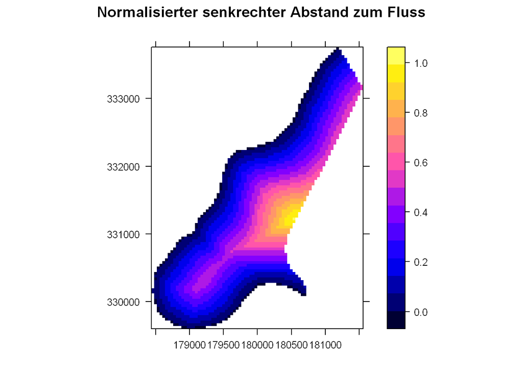

```r
spplot(meuse.grid, z="dist",
       scales=list(draw=T),
       main = "Normalisierter senkrechter Abstand zum Fluss")
```

## Interpolation - IDW

- IDW (Inverse Distanzgewichtung) basiert auf der Annahme, dass die Interpolation von nahen Punkten mehr beeinflusst sein sollte als von weiter entfernten Punkten. Sie ist eine der meist verwendeten Interpolationstechniken.

```r
# Apply the inverse distance weighted interpolation
lead.idw = idw(lead~1, meuse, meuse.grid)
```

```r
class(lead.idw)
```

```
## [1] "SpatialPixelsDataFrame"
## attr(,"package")
## [1] "sp"
```

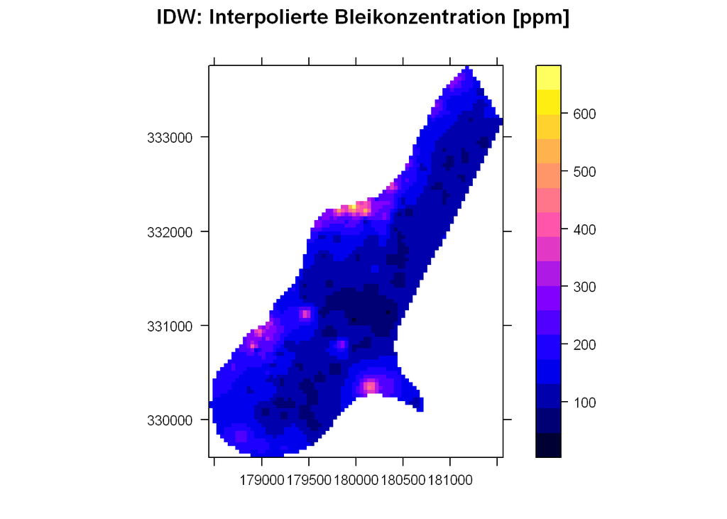

```r
spplot(lead.idw["var1.pred"], scales=list(draw=T),
       main = "IDW: Interpolierte Bleikonzentration [ppm]")
```